# Ecoregion Change Prediction with Neural Networks

Lucas Nerbonne

2025-05-16

# Abstract

My goal for this project is to train a series of neural networks to predict both ecoregion and individual species spatial distribution based on climate and elevation variables. If they can do an adequate job of this, I will test how changing the climate variables, in a completely hypothetical climate warming scenario, changes the predicted distribution of ecoregions and the predicted range of individual species. While not at all predictive of real world potential ecosystem shifts, this is an interesting test to assess the applicability of neural networks in predicting the probable spatial migration initiated by anthropogenic climate alteration.

## The Dataset

# Methods

## Neural Networks

Given that they’re central to our analysis, what are Neural Networks? NN are operations that pass an initial input through a layer (or layers) of decision points that mathmatically abstract the data to help produce a final output. These layers progressively transform the input, extracting patterns that inform the final prediction. There are two basic types of feedforward neural networks: single-layer and multilayer, named for the number of hidden layers they use to process information. Each layer is composed of nodes (neurons, as in neural network), which receive input from the previous layer and produce an output for the next. Each node transforms its input using a combination of weighted sums and nonlinear activation functions, allowing the network to capture complex relationships in the data. After each run through the layer the network assesses it’s output and readjusts the node weights to make a more accurate prediction in the following iteration, allowing it to learn over time.The sheer number of decision points involved in a NN is huge, making them well suited to datasets with a lot of interactions, non-linearity, or have many dimensions.

During the actual training process, a single-layer NN takes three primary parameter inputs: the number of nodes per layer, the number of times the data will be run through the layer of nodes, and a weight decay parameter which helps prevent overfitting by decreasing the emphasis of each node over time as the model gets better overall.

## Data Transformation

The data will be loaded in using the `terra` package, commonly used for raster manipulation. I’m going to only look at the predictive effects of 9 different variables relating to temperature and precipitation on ecoregion distribution, so I pulled the corresponding rasters before combining them with the ecoregion data.

The variables I’m using to predict are somewhat thought out; plant species are often limited by their maximum and minimum survival temperatures (alongside confounding variables like wind) and by precipitation. I’m intentionally not feeding the model locations, because I’m going to ask it to predict NEW locations for the different classes later.

```r
ANNT<-climate[[17]]
ANNT <- as.data.frame(ANNT, xy = TRUE, cells = TRUE, na.rm = TRUE)

TMAX<-climate[[18]]
TMAX <- as.data.frame(TMAX, xy = TRUE, cells = TRUE, na.rm = TRUE)

TMIN<-climate[[19]]
TMIN <- as.data.frame(TMIN, xy = TRUE, cells = TRUE, na.rm = TRUE)

MTCO<-climate[[20]]
MTCO <- as.data.frame(MTCO, xy = TRUE, cells = TRUE, na.rm = TRUE)

MTWA<-climate[[21]]
MTWA <- as.data.frame(MTWA, xy = TRUE, cells = TRUE, na.rm = TRUE)

ANNP<-climate[[34]]
ANNP <- as.data.frame(ANNP, xy = TRUE, cells = TRUE, na.rm = TRUE)

GDD5<-climate[[35]]
GDD5 <- as.data.frame(GDD5, xy = TRUE, cells = TRUE, na.rm = TRUE)

AE_PE<-climate[[36]]
AE_PE <- as.data.frame(AE_PE, xy = TRUE, cells = TRUE, na.rm = TRUE)

elevation<- r[[4]]
elevation <- as.data.frame(elevation, xy = TRUE, cells = TRUE, na.rm = TRUE)

all_regions <- r[[57]]
ecoregions <- as.data.frame(all_regions, xy = TRUE, cells = TRUE, na.rm = TRUE)

ecoregions<- left_join(ecoregions, ANNT, by= c("cell", "x", "y"))
ecoregions<- left_join(ecoregions, TMAX, by= c("cell", "x", "y"))
ecoregions<- left_join(ecoregions, TMIN, by= c("cell", "x", "y"))
ecoregions<- left_join(ecoregions, MTCO, by= c("cell", "x", "y"))
ecoregions<- left_join(ecoregions, MTWA, by= c("cell", "x", "y"))
ecoregions<- left_join(ecoregions, ANNP, by= c("cell", "x", "y"))
ecoregions<- left_join(ecoregions, GDD5, by= c("cell", "x", "y"))
ecoregions<- left_join(ecoregions, AE_PE, by= c("cell", "x", "y"))
ecoregions<- left_join(ecoregions, elevation, by= c("cell", "x", "y"))
```

To test the technique on a smaller subset of the data I’m going to try and predict just the distribution of the first 12 ecoregions, all of which are arctic tundra/boreal forest related. I’ll then map these ecoregions.

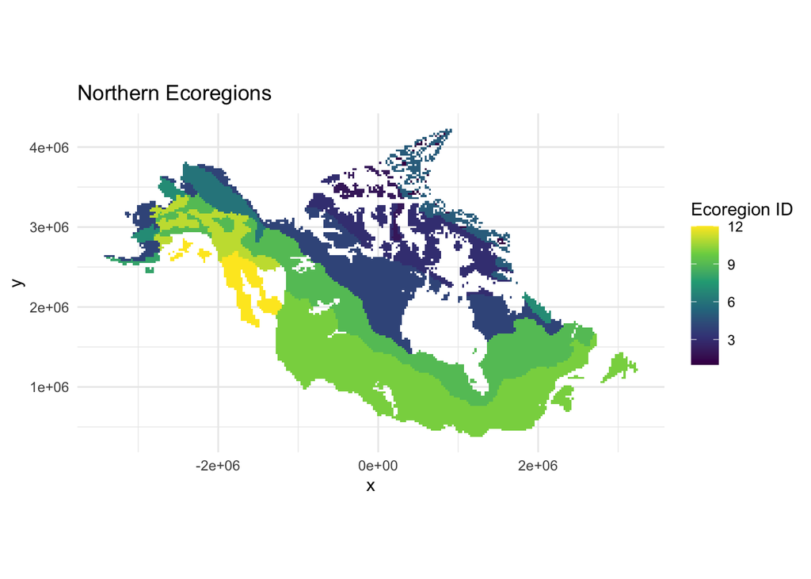

```r
northern<- ecoregions|>
  filter(ALL_BAILEY_ECOREGIONS < 13)

ggplot(northern) +
  geom_raster(aes(x = x, y = y, fill = `ALL_BAILEY_ECOREGIONS`)) +
  coord_equal() +
  scale_fill_viridis_c(name = "Ecoregion ID") +
  theme_minimal() +
  labs(title = "Northern Ecoregions")
```

```r
northern$ALL_BAILEY_ECOREGIONS <- as.factor(make.names(northern$ALL_BAILEY_ECOREGIONS))
ecoregions$ALL_BAILEY_ECOREGIONS <- as.factor(make.names(ecoregions$ALL_BAILEY_ECOREGIONS))
```

We can see that all of the selected ecoregions are generally constrained to Alaska/Canada and are a much smaller subset of our data. I’m going to map a few of our selected variables.

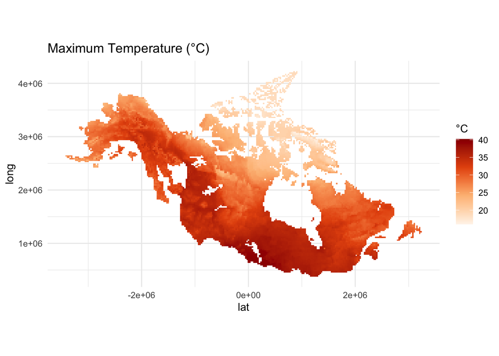

```r
ggplot(northern) +
  geom_raster(aes(x = x, y = y, fill = TMAX)) +
  coord_equal() +
  scale_fill_gradientn(
    colors = c("#FFF5EB", "#FDBE85", "#E6550D", "#990000"),
    name = "\u00B0C")+
  theme_minimal() +
  labs(title = "Maximum Temperature (\u00B0C)", x = "lat",
       y = "long")
```

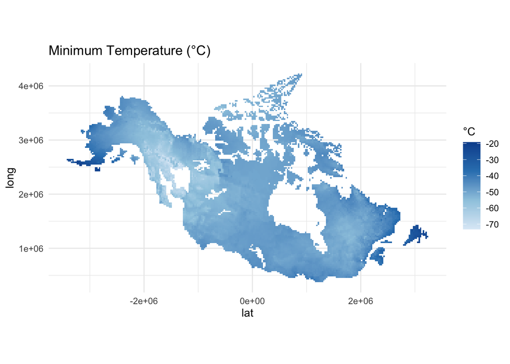

```r
ggplot(northern) +
  geom_raster(aes(x = x, y = y, fill = TMIN)) +
  coord_equal() +
  scale_fill_gradientn(
    colors = c("#DEEBF7", "#9ECAE1", "#3182BD", "#08519C"),
    name = "\u00B0C")+
  theme_minimal() +
  labs(title = "Minimum Temperature (\u00B0C)", x = "lat",
       y = "long")
```

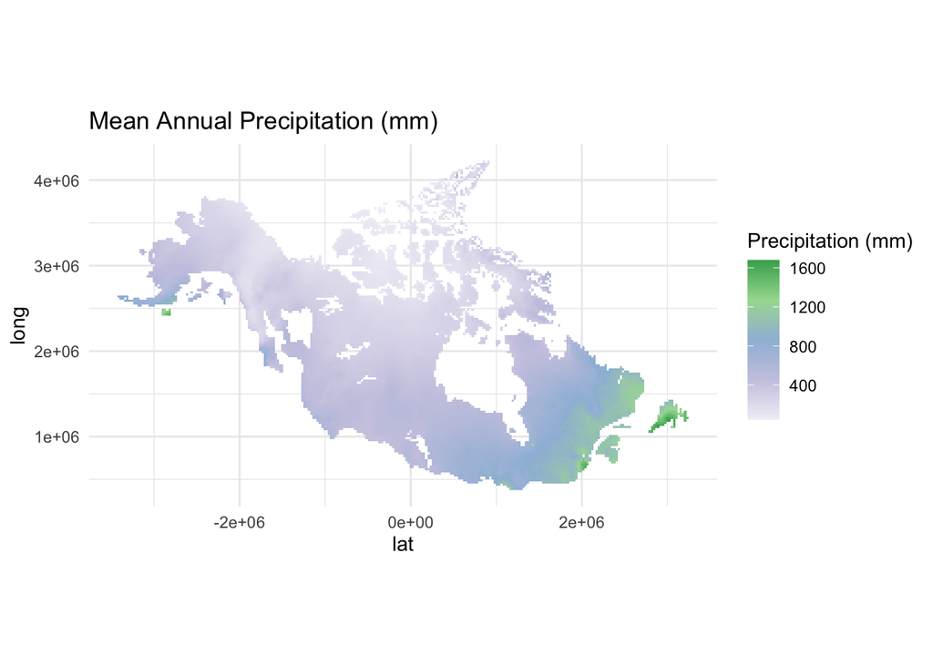

```r
ggplot(northern) +
  geom_raster(aes(x = x, y = y, fill = ANNP)) +
  coord_equal() +
  scale_fill_gradientn(
    colors = c("#F2F0F7", "#CBC9E2", "#9EBCDA", "#A6DBA0", "#41AB5D"),
    name = "Precipitation (mm)")+
  theme_minimal() +
  labs(title = "Mean Annual Precipitation (mm)", x = "lat",
       y = "long")
```

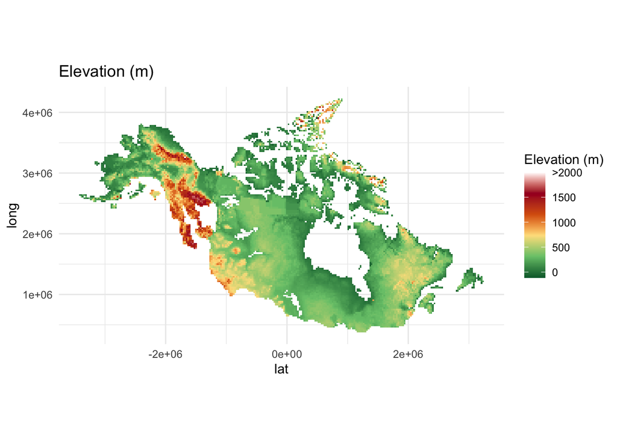

```r
ggplot(northern) +
  geom_raster(aes(x = x, y = y, fill = elevation)) +
  coord_equal() +
  scale_fill_gradientn(
    colors = c("#006837", "#78C679", "#FEE08B", "#D95F0E", "#A50026", "#FFFFFF"),
    limits = c(min(northern$elevation), 2000),
    oob = scales::squish,
    breaks = c(0, 500, 1000, 1500, 2000),
    labels = c("0", "500", "1000",  "1500", ">2000"),
    name = "Elevation (m)"
  ) +
  theme_minimal() +
  labs(title = "Elevation (m)", x = "lat", y = "long")
```

Now that we have an idea of what we’re working with, I will train my first NN on a subset of the data. During this first training I will test a few different node/weight values to see which results in the highest accuracy.

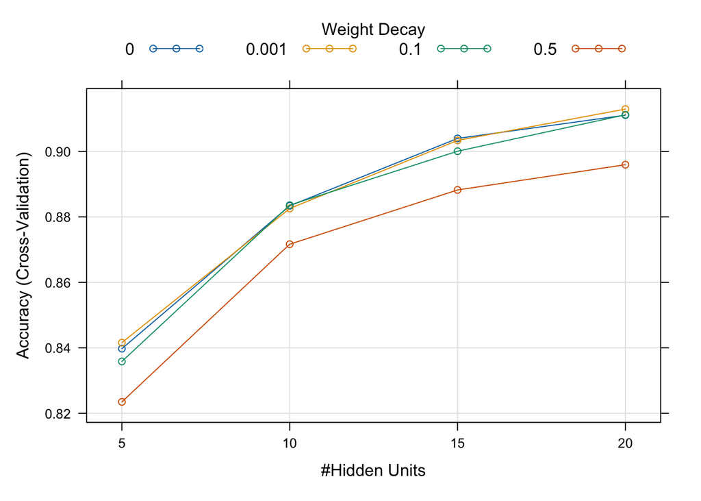

```r
inTrain <- createDataPartition(northern$ALL_BAILEY_ECOREGIONS, p = 3/4)[[1]] #creating a training testing dataset that maintains a proportional partitioning of classes
training <- northern[inTrain,]
testing <- northern[-inTrain,]

registerDoParallel(cores = 2) #running this in parallel so it goes faster
numFolds <- trainControl(
  method = 'cv',      #setting it to run multiple times on subsets of the data to get accuracy
  number = 10,        #setting the number of runs
  classProbs = TRUE,  #telling it to collect the individual probabilities of classes
  verboseIter = TRUE #printing progress
)

tuneGrid = expand.grid(
  size = c(5, 10, 15, 20),
  decay = c(0, 0.1, 0.5, 1e-3)
) #testing the optimal node number and weights on a couple different options

fit1 <- train(`ALL_BAILEY_ECOREGIONS` ~ . -ALL_BAILEY_ECOREGIONS -cell -x -y, data = training, method = 'nnet', preProcess = c('center', 'scale'), trControl = numFolds, tuneGrid= tuneGrid) #training the model

results1 <- predict(fit1, newdata=testing)
conf1 <- confusionMatrix(results1, testing$ALL_BAILEY_ECOREGIONS)
conf1

plot(fit1) #the best fitting weight/node combo was 20 nodes and a weight decay of 0.001 however, due to variable numbers of groups in different parts of the analysis I am choosing to use a lower number of nodes(15) and a higher weight decay (0.01) for the remainder of the analysis
```

Because the NN acts as a black box, we have no idea what variables are being used the most to make our decisions. To test this I will run a random forest to assess variable importance, one of the benefits of a rf model.

```r
rf <- train(
  ALL_BAILEY_ECOREGIONS ~ . - cell - x - y,
  data = training,
  method = "ranger", importance= "impurity"
)

varImp(rf)
```

```
## ranger variable importance
##
##           Overall
## GDD5       100.00
## TMAX        52.65
## ANNT        47.16
## MTWA        44.61
## elevation   36.05
## ANNP        26.83
## MTCO        23.61
## TMIN        12.18
## AEPE         0.00
```

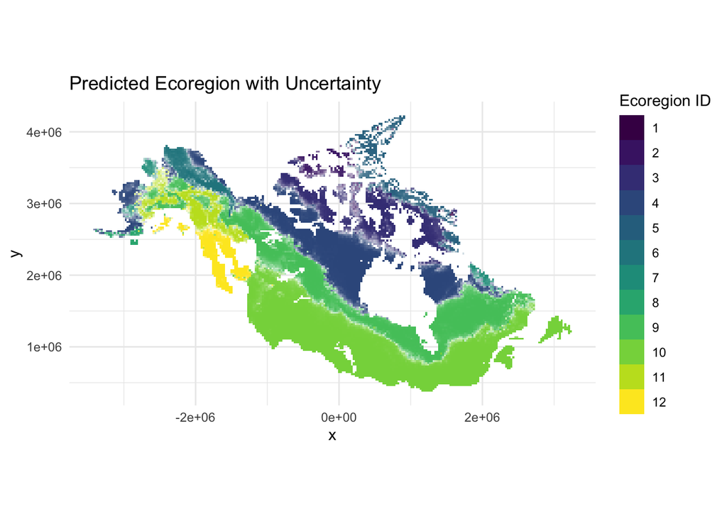

```r
predicted_probs <- predict(fit1, newdata = northern, type = "prob") #soft prediction -- allows us to show the degree of uncertainty in areas

predicted_probs$max_label <- colnames(predicted_probs)[max.col(predicted_probs)]

predicted_probs$opacity <- mapply(
  function(row, colname) predicted_probs[row, colname],
  row = seq_len(nrow(predicted_probs)),
  colname = predicted_probs$max_label
)
predicted_probs$max_label <- sub("^X", "", predicted_probs$max_label)


predicted_probs<- bind_cols(predicted_probs, northern[, 1:3])
predicted_probs$max_label <- factor(predicted_probs$max_label,
                                    levels = sort(as.numeric(unique(predicted_probs$max_label))))


#mapping predicted probability, with opacity determined by the confidence of the prediction
ggplot(predicted_probs) +
  geom_raster(aes(x = x, y = y, fill = `max_label`, alpha = opacity)) +
  coord_equal() +
  scale_fill_viridis_d(name = "Ecoregion ID") +
  theme_minimal() +
  scale_alpha(guide = 'none') +
  labs(title = "Predicted Ecoregion with Uncertainty")
```

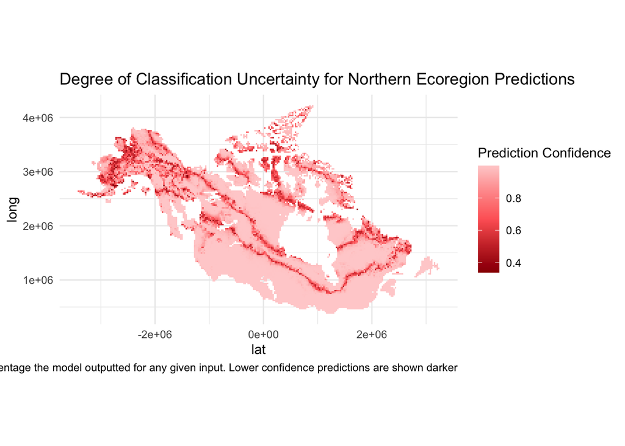

```r
ggplot(predicted_probs) +
  geom_raster(aes(x = x, y = y, fill = `opacity`)) +
  coord_equal() +
  scale_fill_gradientn(
    colors = c("#990000", "#CC3333", "#FF6666", "#FF9999", "#FFD1D1"),
    name = "Prediction Confidence")+
  theme_minimal() +
  labs(title = "Degree of Classification Uncertainty for Northern Ecoregion Predictions", x = "lat",
       y = "long", caption= "The degree of uncertainty a model experienced when making a decision, measured by the regression percentage the model outputted for any given input. Lower confidence predictions are shown darker")
```

We see that the predictions are for the most part accurate, with less confidence at the borders between the ecoregions and in Alaska, where coastal precip and temp patterns that are likely not constrained well by our average precip metric and minimal temperature data beyond extremes.

Now that we know this works, I’m going to train a new model to try the approach on all of the ecoregions.

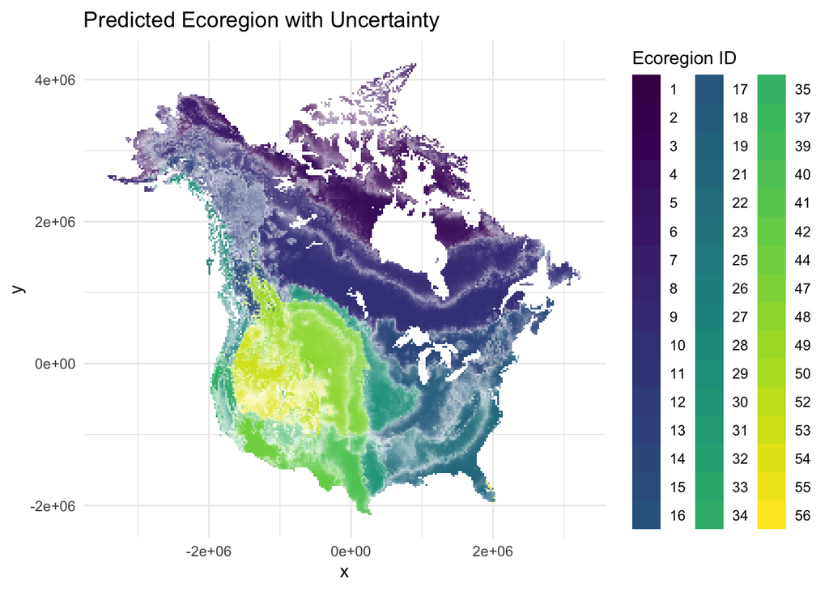

```r
inTrain2 <- createDataPartition(ecoregions$ALL_BAILEY_ECOREGIONS, p = 3/4)[[1]] #creating a training testing dataset that maintains the even partitioning of classes
training2 <- ecoregions[inTrain2,]
testing2 <- ecoregions[-inTrain2,]

fit2 <- train(`ALL_BAILEY_ECOREGIONS` ~ . -ALL_BAILEY_ECOREGIONS -cell -x -y, data = training2, method = 'nnet', preProcess = c('center', 'scale'), trControl = numFolds, tuneGrid=expand.grid(size=c(15), decay=c(0.01)))

results2 <- predict(fit2, newdata=testing2)
conf2 <- confusionMatrix(results2, testing2$ALL_BAILEY_ECOREGIONS)


predicted_probs2 <- predict(fit2, newdata = ecoregions, type = "prob") #soft prediction -- allows us to show the degree of uncertainty in areas

predicted_probs2$max_label <- colnames(predicted_probs2)[max.col(predicted_probs2)]

predicted_probs2$opacity <- mapply(
  function(row, colname) predicted_probs2[row, colname],
  row = seq_len(nrow(predicted_probs2)),
  colname = predicted_probs2$max_label
)
predicted_probs2$max_label <- sub("^X", "", predicted_probs2$max_label)


predicted_probs2<- bind_cols(predicted_probs2, ecoregions[, 1:3])
predicted_probs2$max_label <- factor(predicted_probs2$max_label,
                                    levels = sort(as.numeric(unique(predicted_probs2$max_label))))

ggplot(predicted_probs2) +
  geom_raster(aes(x = x, y = y, fill = `max_label`, alpha = opacity)) +
  coord_equal() +
  scale_fill_viridis_d(name = "Ecoregion ID") +
  theme_minimal() +
  scale_alpha(guide = 'none') +
  labs(title = "Predicted Ecoregion with Uncertainty")
```

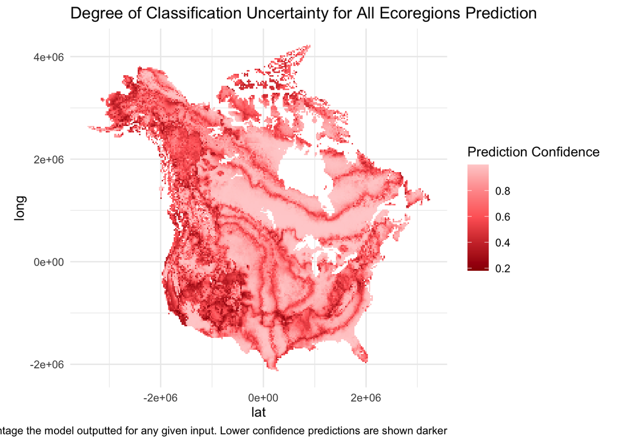

```r
ggplot(predicted_probs2) +
  geom_raster(aes(x = x, y = y, fill = `opacity`)) +
  coord_equal() +
  scale_fill_gradientn(
    colors = c("#990000", "#CC3333", "#FF6666", "#FF9999", "#FFD1D1"),
    name = "Prediction Confidence")+
  theme_minimal() +
  labs(title = "Degree of Classification Uncertainty for All Ecoregions Prediction", x = "lat",
       y = "long", caption= "The degree of uncertainty a model experienced when making a decision, measured by the regression percentage the model outputted for any given input. Lower confidence predictions are shown darker")
```

We see lower, but still alright accuracy levels (kappa = 0.76, accuracy 0.78), and well defined ecoregions mapped by the prediction. The mountain west isn’t well constrained and there is marginally more uncertainty around the edges of regions, but for the most part this model is effective.